# Meiotic drive

## Simulations

Transmission distortion ratio (Shannons TDR stat) in slim sims along with its p-value

X inactivation center is controlled by interacting TAD-D and TAD-E: [^1] [^2]

rDNA copy number correlates with number of mitochondria, like due to mitochondria–nucleus cross-talk, and correlates with gene expression variation, possibly due to rDNA repeats sucking up chromatin mainteance/remodelling factors[^3]

pak3 Expressed in testis, brain, and lung. Functions in cell migration,  
differentiation, and survival.  
2.7/5.1 Stouffs and Lissens (2012)

Could NLGN4Y be an example of a gene adapted to drive in spermatogenesis, with detrimental effects in male brain when there is not a functioning NLGN4X to compelsate? It is at least an example of a both an XI escaper and a gametolog

NLGN4Y is related to testis mas in Mikkels sex chrom paper

DCX, Doublecortin, https://stanford.edu/group/skmlab/styled-4/

Variants studied for autism - ClinVar Miner https://clinvarminer.genetics.utah.edu/variants-by-mondo-condition/5260

PTCHD1  
Sonic Hedgehog: a morphogen involved in axon guidance: R&D Systems  
https://www.rndsystems.com/resources/articles/sonic-hedgehog-morphogen-involved-axon-guidance

Relationship Between Sonic Hedgehog Protein, Brain-Derived Neurotrophic Factor and Oxidative Stress in Autism Spectrum Disorders - PMC  
https://www.ncbi.nlm.nih.gov/pmc/articles/PMC3264868/

Potential crosstalk between sonic hedgehog‐WNT signaling and neurovascular molecules: Implications for blood–brain barrier integrity in autism spectrum disorder - Gozal - 2021 - Journal of Neurochemistry - Wiley Online Library  
https://onlinelibrary.wiley.com/doi/10.1111/jnc.15460

PTCHD1: Identification and Neurodevelopmental Contributions of an Autism Spectrum Disorder and Intellectual Disability Susceptibility Gene - PMC  
https://www.ncbi.nlm.nih.gov/pmc/articles/PMC8953913/

## Genes and associations/properties

- ASD
- Fertility
- nDEG/cDEG
- deltaE
- scRNA expression
- xture

**Strong positive selection drove the introgression of large X-chromosome haplotypes in olive baboons**

- The observation
- Comparison to the autosomal length and frequency distribution of introgressed segments
- Scatter plot with a point for each segment (x-axis: segment length, y-axis: mean admixture proportion in all other individuals in the same segment)
- DAIM evidence that segments were selected
- Possibly Codeml analysis
- Evidence that introgression is from AEA (use analysis from flagship paper, maybe do Relate analysis on the segments)

**Mail from Anne**  
There are many papers and reviews that describe the dynamic of the FMR1 alleles across generations and how instability in the grey/intermediate zone leads to full expansion in the female germline. An important aspect that has come out in the last decade is that the intermediate alleles are also associated with a phenotype called FAXTAS (Fragile X-associated tremor/ataxia syndrome) and in females is also associated with premature ovarian insufficiency (FXPOI). Because the intermediate alleles in oocytes are deleterious (premature ovarian failure), the full mutations are selected for in the female germline – which explained the maternal transmission of full alleles and genetic anticipation.  
On the male side, things are different, and variation occurs in the normal to grey/intermediate zone only (PMCID: http://www.ncbi.nlm.nih.gov/pmc/articles/pmc1914886/ ) – but interestingly, grey/intermediate fathers never transmit full mutations to their daughters – moreover, in the sperm of Frax male with full mutations (in blood), the allele is always retracted in sperm and testes – suggesting that there is a negative selection on full mutations in the male germline (doi: 10.1038/ng0693-143).  
This article indirectly suggests that selection may be taking place in culture ·· DOI: https://doi.org/10.1136/jmg.37.11.842

There are lots of old papers that look at the distribution of alleles in the population. The striking thing to me is how polymorphic this site is and how common the ‘grey zone’ alleles are – I think it is estimated that the prevalence of ’expanded grey zone (40-54CGG) is 1:18 females and 1:32 males.

Macro-orchidism is a diagnostic criterion of FraX in males – this is also observed in mouse model. The old descriptions are probably the most comprehensive -you can start with this maybe? · DOI: https://doi.org/10.1007/bf00284911

Hope this helps to get you started and this is what you were after? - it sounds complicated but it is worth trying to pick things apart.  
Let me know if you want to discuss further ?

Notes  
There are almost no pachytene peak genes on X. So ancestral autosomal ones must have changed their expression or where moved off X.

**TODO:**  
**Label each gene as circDNA if it is**

… and RBMX2 “Enables RNA binding activity. Involved in mRNA splicing, via spliceosome. Located in nucleus.  
Part of U2-type precatalytic spliceosome (gene card)” (which is the above-mentioned processing machinery…)

X-linked palindromic gene families 4930567H17Rik and Mageb5 are dispensable for male mouse fertility - PubMed  
https://pubmed.ncbi.nlm.nih.gov/35595785/

A model and test for coordinated polygenic epistasis in complex traits | PNAS  
https://www.pnas.org/doi/10.1073/pnas.1922305118

X-linked palindromic gene families 4930567H17Rik and Mageb5 are dispensable for male mouse fertility - PubMed https://pubmed.ncbi.nlm.nih.gov/35595785/  
A model and test for coordinated polygenic epistasis in complex traits | PNAS https://www.pnas.org/doi/10.1073/pnas.1922305118

https://www.readcube.com/library/ff394a98-20f7-4882-871c-840e9f73d65b:932c2460-f897-46ba-b3f1-76358eaf2077

PCYT1B also diff expressed…

## CENHAPS

- Autosomal CENHAPS could be drivers in females
- X CENHAPS could be drivers in males
- The allele dynamics could work as in my simulations if each pair of CENHAPS have separate drives against each other.
- Could be responding to DYNLT3 as driver
- Could be tracking DYNLT3 back and forth between modern and archaics
- Could it be chrX cenhap that triggers Dynein adaptation, that triggers other chaps?
- Could it be simpler? That it is the Dyneins (or other) drivers that the frequency-dependent selection operates on - and that the CENHAPS just track the proportions of the drivers in a way that on average give an even transmission. So the chrX CENHAPS and their frequencies would *counter* the X distortions produced by the DYNLT3 as well as the associated distortions on autosomes.
- What would the predictions be? Should all the cenhaps have similar divergence? Should they track DYNLT3 (and maybe DYNLT1)? Should all chromosomes have archaic cenhaps?

If all cenhaps track the frequenciess same spindle proteins, then each chromosome should have the same frequency distribution of cenhaps. - but then again, maybe not, if cenhaps at each chromosome fit with spindle proteins in different ways…

## Evolutionary strata on X

As we discussed, it is pretty amazing that the even X/Y transmission in spermatogenesis works at all if all an X (or Y) gene, essential to late spermatids/spermatozoa, needs to do is delay its expression until it can no longer be shared with cells with the Y (or X), instead of expressing early and handing it to the Y (or X) it through the chromatoid body. It must have taken a lot of selection to ensure this did not happen, as additional X and Y chromosome chunks stopped recombining. Maybe by moving offending genes to the autosomes, by adding compensating gametologs to the other sex chromosome (like VCY copied from VCX in the human-chimp ancestor), or by moving control of X and Y genes the autosomes (like PRDM9 seems to affect VCX transcription). On the other hand, the sex chromosomes will have opposed these processes, E.g., by duplicating genes (like SLY/SLX in mice). As you said, it may be possible to see these processes play out by looking at the expression of genes lost and duplicated and whether the time of loss/gain of genes relevant to spermatogenesis correlates with the time of the different strata on X.

Why are there so few syntenic changes on X? A new segregating Y inversion will can be targetet by X drivers. So inversions only happen if the Y inversion can itself drive. Same would go for X inversions I guess…

Maybe drivers are what keeps the PARs from shrinking. The latest one could be SHROOM2

## Evidence for adaptive higher admixture or invasions in stratum 4

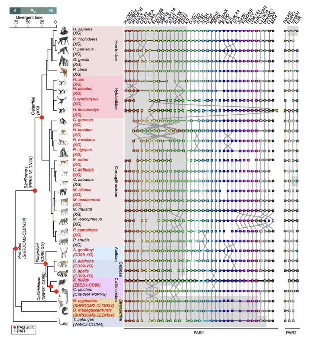

(Mikkels sex chrom paper)

It looks like Denisovan introgression into aborigines was selected for in stratum 4 and selected against in the remaining chromosome:

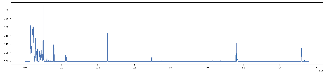

(neanderthal-human-admixture project)

It looks like high ILS among *Cercopithecini* (and to some extent among *Papionini*) on the p arm is confined to stratum 4. Also, the branch to non-*Simiiformes* primates, which have PAR in stratum 4, has low high ILS there (maybe just because of the higher Ne of PARs).

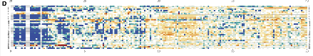

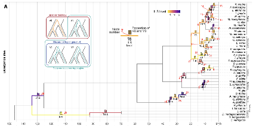

(Ikers ILS paper)

Are genes on new strata co-regulated? A new stratum added “in one go” would be a sum of many small challenges and would be addressed by countermeasures that could address them collectively.

## MSCI-XCI link

The human inactive X chromosome modulates expression of the active X chromosome [(Roman et al. 2023)](https://app.readcube.com/library/ff394a98-20f7-4882-871c-840e9f73d65b/all?uuid=5842494524609508&item_ids=ff394a98-20f7-4882-871c-840e9f73d65b:544294c6-8c74-4645-b80e-08382e60fa6c)

Landscape of DNA methylation on the X chromosome reﬂects CpG density, functional chromatin state and X-chromosome inactivation [(Cotton et al. 2015)](https://app.readcube.com/library/ff394a98-20f7-4882-871c-840e9f73d65b/all?uuid=5552152807218244&item_ids=ff394a98-20f7-4882-871c-840e9f73d65b:d8f399d9-de89-418d-822b-626290648115)

Skewed X-chromosome inactivation in unsolved neurodevelopmental disease cases can guide re-evaluation For X-linked genes [(Shvetsova et al. 2019)](https://app.readcube.com/library/ff394a98-20f7-4882-871c-840e9f73d65b/all?uuid=8320874248576191&item_ids=ff394a98-20f7-4882-871c-840e9f73d65b:255e9278-759f-404c-8c47-c292bf06d434)

Autosomal genetic variation is associated with DNA methylation in regions variably escaping X chromosome inactivation [(Luijk et al. 2018)](https://app.readcube.com/library/ff394a98-20f7-4882-871c-840e9f73d65b/all?uuid=8065918584618268&item_ids=ff394a98-20f7-4882-871c-840e9f73d65b:618b6abb-9f98-4669-bce1-c98623aa5743) (see notes under ALG13 below)

## X-Mitochondria link

**Info from Dan:**

- Dans number +972-54-2376883
- MitoCarta
- Ophry Pines
- Blumberg 2014 GBE
- MOF, NFATC, MEF2D, MFN1, MFN2, DRP1
- Mitochondrial fission and fusion
- Orian Shirihai UCLA
- Tom Schwartz

Patterns of Ancestry, Signatures of Natural Selection, and Genetic Association with Stature in Western African Pygmies [(Jarvis et al. 2012)](https://app.readcube.com/library/ff394a98-20f7-4882-871c-840e9f73d65b/all?uuid=7542605493828415&item_ids=ff394a98-20f7-4882-871c-840e9f73d65b:0b451f6a-d239-4c39-c62d-ac5526bcde8a)

Tunneling Nano Tubes (TNT) is a thing…  
Is there a fixed number of mitochondia that are packed in the flagellum engine or is always better to have more?  
X–Y Interactions Underlie Sperm Head Abnormality in Hybrid Male House Mice https://www.ncbi.nlm.nih.gov/pmc/articles/PMC3982709/  
Disrupted Gene Networks in Subfertile Hybrid House Mice | Molecular Biology and Evolution | Oxford Academic https://academic.oup.com/mbe/article/37/6/1547/5735471?login=false

- Read paper cliff sent
- Read kipunji paper
- see if siepels data support AR introgression into neanderthals
- see if eriks AR introgression only affects the yellows that got the olive mtDNA
- Maybe both swamping and capture can be true at the same time. Swamping suggested by observation and eriks results, and capture in the other direction.
- mail melissa about traks
- see if adaptive AR introgression in baboons is about the same age as olive-northernyellow mdDNA divergence
- Figure out why there are no mtDNA for all the samples.
- [Located at midpiece in human sperm](https://academic.oup.com/humrep/article/20/12/3481/2913811?login=true) although it seems almost without expression in spermatogeneis (kaessman data). [Fron mice](https://www.readcube.com/library/ff394a98-20f7-4882-871c-840e9f73d65b:3b9c82a2-ca5b-481c-a6a8-802a76b95cd2) it seems AR is not expressed in sperm cells but transported into them from other cells. If that is so, AR can not be a driver. It must follow the introgressing mitochrondrion, but then what does the MT follow?

https://journals.physiology.org/doi/full/10.1152/ajpcell.00205.2022?utm_term=apspublications&utm_campaign=American_Journal_of_Physiology_-_Cell_Physiology_TrendMD_1&utm_medium=cpc&utm_source=TrendMD&utm_content=16880be5-051c-4755-a68b-4e5d410aeaff  
FMR1 (Fragile X mental retardation) in largest region [Recent work by Licznerski et al. suggests that mutant FMRP linked to Fragile-X syndrome elevates the inner mitochondrial membrane proton leak](https://www.readcube.com/library/ff394a98-20f7-4882-871c-840e9f73d65b:9ec413b0-138d-49e4-8a48-74c1b66dd42d) Refers to: [Refers to this paper describing it: ATP Synthase c-Subunit Leak Causes Aberrant Cellular Metabolism in Fragile X Syndrome](https://www.readcube.com/library/ff394a98-20f7-4882-871c-840e9f73d65b:7c646861-1095-482f-a3d3-59a129f42b44)

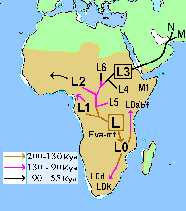

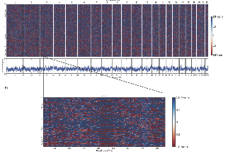

[figure not shown]

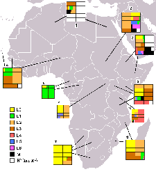

## Human-Neanderthal admixture

If the reason much less X than A admixture passed from N to H because the N Y was not introgressed as well, then the X regions interacting with Y should explain the Excess X (over A) hum regions introgressed into nean when the hum Y followed into Nean. Those regions could be candidates for incompatibility and/or drive

Two explanqations:

1. Drive
2. That some X regions that fit the foreign Y are positively selected

Alternative explanation arguing for mutation load in MT: ”The on-again, off-again relationship between mitochondrial genomes and species boundaries” [(Sloan et al. 2017)](https://app.readcube.com/library/ff394a98-20f7-4882-871c-840e9f73d65b/all?uuid=4609899209742542&item_ids=ff394a98-20f7-4882-871c-840e9f73d65b:c83be9c1-b215-4433-8b09-6bda3e0ae7bd)

## circRNA

The Output of Protein-Coding Genes Shifts to Circular RNAs When the Pre-mRNA Processing Machinery Is Limiting [(Liang et al. 2017)](https://app.readcube.com/library/ff394a98-20f7-4882-871c-840e9f73d65b/all?uuid=7424630405799709&item_ids=ff394a98-20f7-4882-871c-840e9f73d65b:20830a9b-595c-4afb-ad3e-b193b9b49e94)

## Anti-sense transcript regulation

https://app.readcube.com/library/ff394a98-20f7-4882-871c-840e9f73d65b/all/(sidepanel:details)?item_id=a9d55794-cdc5-4c82-b955-224d9ee138ed&collection_id=ff394a98-20f7-4882-871c-840e9f73d65b

## ASD / ADHD

Intellectual disability genes:  
[X-Linked Intellectual Disabilities Sequencing and Deletion/Duplication Panel](https://knightdxlabs.ohsu.edu/home/test-details?id=X-Linked+Intellectual+Disabilities+Sequencing+and+Deletion%2FDuplication+Panel)  
ACSL4, **AFF2**, AP1S2, ARHGEF9, ARX, ATP6AP2, **ATP7A**, **ATRX**, BCOR, BRWD3, CASK, CCDC22, CDKL5, CLIC2, **CNKSR2**, CUL4B, **DCX**, DKC1, DLG3, DMD, **FANCB**, FGD1, FLNA, FMR1, FRMPD4, FTSJ1, GDI1, GK, GPC3, GRIA3, HCCS, HPRT1, HSD17B10, **HUWE1**, IDS, IGBP1, IL1RAPL1, IQSEC2, **KDM5C**, KIAA2022, L1CAM, LAMP2, **MAOA**, MBTPS2, MECP2, MED12, MID1, NAA10, NDP, NDUFA1, NHS, NLGN3, **NLGN4X**, NSDHL, OCRL, OFD1, **OPHN1**, OTC, **PAK3**, PCDH19, PDHA1, PGK1, **PHF6**, **PHF8**, PLP1, PORCN, PQBP1, PRPS1, PTCHD1, RAB39B, RBM10, RPL10, RPS6KA3, SHROOM4, SLC16A2, SLC9A6, **SMC1A**, SMS, SOX3, SYN1, SYP, TIMM8A, TSPAN7, UBE2A, UPF3B, **ZDHHC15**, ZDHHC9, ZNF711

## Alzheimers

Sex differences in Alzheimer’s disease: metabolic reprogramming and therapeutic intervention [(Demetrius et al. 2021)](https://app.readcube.com/library/ff394a98-20f7-4882-871c-840e9f73d65b/all?uuid=8686880842280787&item_ids=ff394a98-20f7-4882-871c-840e9f73d65b:e1a22da0-e731-4ac2-be6a-ef414f2350d2)

TODO: Investigate the link between X-MT and Alzheimers (just search smart cite with “Alzheimers”)

SHMOOSE microprotein (A model and test for coordinated polygenic epistasis in complex traits; Aitken & Koppers 2010; Bonnet et al. 2017; Chalkia et al. 2017; Cohen et al. 2016; Fernandes et al. 2006; Licznerski et al. 2020; Luijk et al. 2018; Mandal & Drerup 2019; Miller et al. 2022; Nardello et al. 2021; Nguyen et al. 2020; Olson et al. 2008; Paulsen et al. 2022; Polla et al. 2019; Sakellakis & Flores 2022; Seif et al. 2021; Silva et al. 2015; Stefansson et al. 2005; Zhang et al. 2019)

## Male fertility and the X chromosome

Large-scale analyses of the X chromosome in 2,354 infertile men discover recurrently affected genes associated with spermatogenic failure: [(Riera-Escamilla et al. 2022)](https://app.readcube.com/library/ff394a98-20f7-4882-871c-840e9f73d65b/all?uuid=8210731900920802&item_ids=ff394a98-20f7-4882-871c-840e9f73d65b:7d29268e-e489-4ad2-9789-2b4f795654cb) **Mentions many of the candidate drivers…**

The X chromosome and male infertility: [(Vockel et al. 2019)](https://app.readcube.com/library/ff394a98-20f7-4882-871c-840e9f73d65b/all?uuid=7583616762864487&item_ids=ff394a98-20f7-4882-871c-840e9f73d65b:f68903fc-fa7c-439d-a901-0c1acad09e88)

**Pos sel.** (ECH, relate, ILS, Codeml)  
cDEG  
*Gametolog*  
-deltaE, +deltaE,  
Spermatogenesis (expression, association)

## Interesting genes

*Gene labels:*  
*ECH-13: In Simons peak 13*  
*nDEG: Differentially expressed in X and Y sperm (only in the nucleus)*  
*cDEG: Differentially expressed in X and Y sperm (in the nucleus and the cytoplasm)*  
*XY-homolog: X gene has homolog on Y*  
*+deltaE, -deltaE: Changes expression + or - in response to additional inactive X chromosomes*  
*HN-introgression: introgressed from humans into neanderthals ~250,000 BP*  
*circRNA: Predicted circRNA*  
*ASD: linked to the Autism Spectrum Disorder*  
*ADHD: linked to the Attention deficit hyperactivity disorder*  
*ID: Neurodevelopmental disorder, intellectual disability*  
*AD: Alzheimer’s disease*

## Gene list

*(To show/hide gene notes: right-click a header below and choose Expand/Collapse all headings of same style)*

#### **ACTRT1**

- *ECH-15*
- ACTRT is upregulated in Sly-deficient mice [(Riel et al. 2012)](https://app.readcube.com/library/ff394a98-20f7-4882-871c-840e9f73d65b/all?uuid=7046788372997634&item_ids=ff394a98-20f7-4882-871c-840e9f73d65b:7b07e113-f1af-48e0-bfa5-d99b654b2003)
- Loss of perinuclear theca ACTRT1 causes acrosome detachment and severe male subfertility in mice [(Zhang et al. 2022)](https://app.readcube.com/library/ff394a98-20f7-4882-871c-840e9f73d65b/all?uuid=8800565728821632&item_ids=ff394a98-20f7-4882-871c-840e9f73d65b:af3bd714-39d1-468f-8f3c-ac130073255b)
- Sonic hedgehog pathway inhibition alters epididymal function as assessed by the development of sperm motility [(Turner et al. 2006)](https://app.readcube.com/library/ff394a98-20f7-4882-871c-840e9f73d65b/all?uuid=6164812190588083&item_ids=ff394a98-20f7-4882-871c-840e9f73d65b:01725a61-f039-4746-88a1-aeed37240362). Mutations in ACTRT1 and its enhancer RNA elements lead to aberrant activation of Hedgehog signaling in inherited and sporadic basal cell carcinomas (Bal et al. 2017; Turner et al. 2006). P53 Modulates The Activity Of The GLI1 Oncogene Through Interactions With The Shared Coactivator TAF9 [(Yoon et al. 2015)](https://app.readcube.com/library/ff394a98-20f7-4882-871c-840e9f73d65b/all?uuid=18054467472315572&item_ids=ff394a98-20f7-4882-871c-840e9f73d65b:0aadb9cc-3da2-4edf-bb1c-91f6f13faaad). Ectopic expression of Sonic Hedgehog in a cryptorchid man with azoospermia: a case report [(Zou et al. 2013)](https://app.readcube.com/library/ff394a98-20f7-4882-871c-840e9f73d65b/all?uuid=37109303803840654&item_ids=ff394a98-20f7-4882-871c-840e9f73d65b:f069debd-bd6a-456e-aa24-47c645a2de5a)
- Sonic hedgehog pathway genes are expressed and transcribed in the adult mouse epididymis [(Turner et al. 2006)](https://app.readcube.com/library/ff394a98-20f7-4882-871c-840e9f73d65b/all?uuid=16384831221617913&item_ids=ff394a98-20f7-4882-871c-840e9f73d65b:01725a61-f039-4746-88a1-aeed37240362)

#### **AFF2**

- Fragile X Mental Retardation 2
- This is probably the driver
- [gene card](https://www.genecards.org/cgi-bin/carddisp.pl?gene=AFF2)
- nDEG+cDEG, *, circRNA*
- ASD gene
- AFF2 [interact with CTNNB1](http://www.ncbi.nlm.nih.gov/pubmed/30361391) (also sperm expresed) which in turn binds AR (many papers on STRING)
- So maybe: AFF2 drives, pulls along CTNNB1, which then pulls AR, which then pulls MT. But what made it stop halfway through the yellows???

#### **AKAP4**

- *ECH-5, circRNA*

#### **ALG13**

- *ECH-13, nDEG,*
- Autosomal genes SMCHD1/METTL4 and TRIM6/HBG2 are associated with *hypo*-methylation of CpG islands near **ALG13 (cDEG)** (and associated with increased expression): Autosomal genetic variation is associated with DNA methylation in regions variably escaping X chromosome inactivation [(Luijk et al. 2018)](https://app.readcube.com/library/ff394a98-20f7-4882-871c-840e9f73d65b/all?uuid=9242674075575511&item_ids=ff394a98-20f7-4882-871c-840e9f73d65b:618b6abb-9f98-4669-bce1-c98623aa5743) (Also involves **CXorf22 (nDEG), IQSEC2 (cDEG), SYP (cDEG) TBL1X (deltaE), TMSBAX (deltaE, nDEG), PRKX (deltaE), SMC1A (deltaE), BEX2 (nDEG)**) (*4 deltaE genes…*)

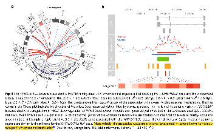

#### *ATRX*

- *ECH-11, nDEG*

#### AR

- *Baboon-introgression*

#### **BCLAF3**

- *ECH-1, nDEG, ~HN-introgression, circRNA*
- *Ari Relate GWD*

#### **CFAP47** / **CXorf22** / **CXorf30**

- *ECH-3, nDEG*
- Autosomal genes TRIM6/HBG2 are associated with *hyper-*methylation of CpG islands near CFAP47 [(Luijk et al. 2018)](https://app.readcube.com/library/ff394a98-20f7-4882-871c-840e9f73d65b/all?uuid=33474269799429635&item_ids=ff394a98-20f7-4882-871c-840e9f73d65b:618b6abb-9f98-4669-bce1-c98623aa5743)
- CFAP47 “associate” with CFAP65 in STRING (and PCDH11X which is is sfari)
- CFAP65:[A novel homozygous CFAP65 mutation in humans causes male infertility with multiple morphological abnormalities of the sperm flagella](https://onlinelibrary.wiley.com/doi/10.1111/cge.13644), [Connecting phenotype to genotype: PheWAS-inspired analysis of autism spectrum disorder](https://www.ncbi.nlm.nih.gov/pmc/articles/PMC9605200/)

#### **CHIC1**

- *ECH-9, nDEG*

#### **CNKSR2**

- *ECH-2, HN-introgression*

#### **DYNLT3**

- *ECH-4, nDEG*

#### *DDX3X*

- *XY-homolog, +deltaE, nDEG, circRNA*
- Missing DDX3Y makes men sterile. It is an amplicon in Mikkel’s sex chromosome paper. It is a circRNA with connection to ASD [(Chen et al. 2020)](https://app.readcube.com/library/ff394a98-20f7-4882-871c-840e9f73d65b/all?uuid=5936054453006911&item_ids=ff394a98-20f7-4882-871c-840e9f73d65b:6b20ea46-40fc-4d70-b0a3-146abb6a630c)
- DDX3Y is linked to intelectual developmental disorder (gene card)

#### *EIF1AX*

- *ECH-1, nDEG, cDEG, XY-homolog, +deltaE, HN-introgression,*
- *Ari Relate GWD*

#### **F8**

- *ECH-19, -delta-E*

#### **IL13RA2**

- *ECH-14, nDEG, cDEG*
- *codeml*

#### *KDM6A* / *UTX*

- *XY-homolog, +deltaE, nDEG*
- Loss of KDM6A Activates Super-Enhancers to Induce Gender-Specific Squamous-like Pancreatic Cancer and Confers Sensitivity to BET Inhibitors [(Andricovich et al. 2018)](https://app.readcube.com/library/ff394a98-20f7-4882-871c-840e9f73d65b/all?uuid=22822390551819915&item_ids=ff394a98-20f7-4882-871c-840e9f73d65b:81b5c4e9-04f1-4887-ba1d-1d3251161c69)

#### *KDM5C*

- *XY-homolog, +deltaE*

#### **LAS1L**

- *ECH-8, nDEG*

#### **LRCH2**

- *ECH-14, nDEG,*

#### *PGK1*

- *ECH-11, nDEG,*

#### **PHF8**

- *ECH-7, nDEG, circRNA*

#### **PRKX**

- *XY-homolog, +deltaE, Relate YRI,*

#### *NLGN4X*

- *XY-homolog, HN-introgression, circRNA*
- This paper https://www.readcube.com/library/ff394a98-20f7-4882-871c-840e9f73d65b:9d790856-8ad1-4ee3-927f-f199a6441b43 links NLGN4X (SYN1 and MECP2) schizophreny in males. Also shows that the genes are hypomethylated in affecged male and significantly overlapped with gene locations where Xinactivation escapism was observed in women

#### **RBMX**

- *ECH-16*

#### SMC1A

- *circRNA*
- Autosomal genes TRIM6/HBG2 are associated with *hypo*-methylation of CpG islands near SMC1A (and associated with increased expression) [(Luijk et al. 2018)](https://app.readcube.com/library/ff394a98-20f7-4882-871c-840e9f73d65b/all?uuid=2819821286444666&item_ids=ff394a98-20f7-4882-871c-840e9f73d65b:618b6abb-9f98-4669-bce1-c98623aa5743)

#### *TXLNG*

- *XY-homolog, +deltaE, circRNA*

#### *USP9X*

- *XY-homolog, +deltaE, nDEG*

#### *RPS4X*

- *XY-homolog, +deltaE*

#### *TGIF2LX*

- *XY-homolog, nDEG*
- *codeml*

#### P2RY10

#### FIRRE

#### DXZ4 / DANT2

- *SFARI gene*

#### **Xist**

#### *ZFX*

- *XY-homolog, +deltaE*

#### **ZCCHC13**

- *ECH-9, nDEG*

#### **PTCHD1**

- Ari Relate LWK,GWD,YRI

#### **PTCHD1-AS**

- Ari Relate GWD

#### **DMD**

- Ari Relate GWD

#### **IL1RAPL1**

- Ari Relate GWD

**CDKL5**

- Ari Relate ESN,YRI

#### TAF1

#### SYP

#### FMR1

IQSEC2

TBL1X

TMSBAX

- nDEG

**PRKX**

- Ari Relate GWD

SMC1A

BEX2

- nDEG

#### **LOC105373153**

- Ari Relate YRI

#### ZNF711

#### PUDP

#### HTR2C

## References

A model and test for coordinated polygenic epistasis in complex traits  
Aitken RJ, Koppers AJ. 2010. Apoptosis and DNA damage in human spermatozoa. *Asian J Androl*. 13(1):36–42  
Andricovich J, Perkail S, Kai Y, Casasanta N, Peng W, Tzatsos A. 2018. Loss of KDM6A Activates Super-Enhancers to Induce Gender-Specific Squamous-like Pancreatic Cancer and Confers Sensitivity to BET Inhibitors. *Cancer Cell*. 33(3):512-526.e8  
Bal E, Park H-S, Belaid-Choucair Z, Kayserili H, Naville M, et al. 2017. Mutations in ACTRT1 and its enhancer RNA elements lead to aberrant activation of Hedgehog signaling in inherited and sporadic basal cell carcinomas. *Nat Med*. 23(10):1226–33  
Bonnet T, Leblois R, Rousset F, Crochet P. 2017. A reassessment of explanations for discordant introgressions of mitochondrial and nuclear genomes. *Evolution*. 71(9):2140–58  
Chalkia D, Singh LN, Leipzig J, Lvova M, Derbeneva O, et al. 2017. Association Between Mitochondrial DNA Haplogroup Variation and Autism Spectrum Disorders. *Jama Psychiat*. 74(11):1161  
Chen Y-J, Chen C-Y, Mai T-L, Chuang C-F, Chen Y-C, et al. 2020. Genome-wide, integrative analysis of circular RNA dysregulation and the corresponding circular RNA-microRNA-mRNA regulatory axes in autism. *Genome Res*. 30(3):375–91  
Cohen T, Levin L, Mishmar D. 2016. Ancient Out-of-Africa Mitochondrial DNA Variants Associate with Distinct Mitochondrial Gene Expression Patterns. *Plos Genet*. 12(11):e1006407  
Cotton AM, Price EM, Jones MJ, Balaton BP, Kobor MS, Brown CJ. 2015. Landscape of DNA methylation on the X chromosome reflects CpG density, functional chromatin state and X-chromosome inactivation. *Hum Mol Genet*. 24(6):1528–39  
Demetrius LA, Eckert A, Grimm A. 2021. Sex differences in Alzheimer’s disease: metabolic reprogramming and therapeutic intervention. *Trends Endocrinol Metabolism*. 32(12):963–79  
Fernandes CA, Rohling EJ, Siddall M. 2006. Absence of post‐Miocene Red Sea land bridges: biogeographic implications. *J Biogeogr*. 33(6):961–66  
Jarvis JP, Scheinfeldt LB, Soi S, Lambert C, Omberg L, et al. 2012. Patterns of Ancestry, Signatures of Natural Selection, and Genetic Association with Stature in Western African Pygmies. *PLoS Genetics*. 8(4):e1002641  
Liang D, Tatomer DC, Luo Z, Wu H, Yang L, et al. 2017. The Output of Protein-Coding Genes Shifts to Circular RNAs When the Pre-mRNA Processing Machinery Is Limiting. *Mol Cell*. 68(5):940-954.e3  
Licznerski P, Park H-A, Rolyan H, Chen R, Mnatsakanyan N, et al. 2020. ATP Synthase c-Subunit Leak Causes Aberrant Cellular Metabolism in Fragile X Syndrome. Cell. 182(5):1170-1185.e9  
Luijk R, Wu H, Ward-Caviness CK, Hannon E, Carnero-Montoro E, et al. 2018. Autosomal genetic variation is associated with DNA methylation in regions variably escaping X-chromosome inactivation. *Nat Commun*. 9(1):3738  
Mandal A, Drerup CM. 2019. Axonal Transport and Mitochondrial Function in *Neuron*s. *Front Cell Neurosci*. 13:373  
Miller B, Kim S-J, Mehta HH, Cao K, Kumagai H, et al. 2022. Mitochondrial DNA variation in Alzheimer’s disease reveals a unique microprotein called SHMOOSE. *Mol Psychiatr*. 1–14  
Nardello R, Antona V, Mangano GD, Salpietro V, Mangano S, Fontana A. 2021. A paradigmatic autistic phenotype associated with loss of PCDH11Y and NLGN4Y genes. *Bmc Med Genomics*. 14(1):98  
Nguyen TA, Wu K, Pandey S, Lehr AW, Li Y, et al. 2020. A Cluster of Autism-Associated Variants on X-Linked NLGN4X Functionally Resemble NLGN4Y. Neuron. 106(5):759-768.e7  
Olson LE, Sargis EJ, Stanley WT, Hildebrandt KBP, Davenport TRB. 2008. Additional molecular evidence strongly supports the distinction between the recently described African primate Rungwecebus kipunji (Cercopithecidae, Papionini) and Lophocebus. *Mol Phylogenet Evol*. 48(2):789–94  
Paulsen B, Velasco S, Kedaigle AJ, Pigoni M, Quadrato G, et al. 2022. Autism genes converge on asynchronous development of shared neuron classes. *Nature*. 602(7896):268–73  
Polla DL, Saunders HR, Vries BBA, Bokhoven H, Brouwer APM. 2019. A de novo variant in the X‐linked gene CNKSR2 is associated with seizures and mild intellectual disability in a female patient. *Mol Genetics Genom Medicine*. 7(10):e00861  
Riel JM, Yamauchi Y, Sugawara A, Li HYJ, Ruthig V, et al. 2012. Deficiency of the multi-copy mouse Y gene Sly causes sperm DNA damage and abnormal chromatin packaging. *J Cell Sci*. 126(3):803–13  
Riera-Escamilla A, Vockel M, Nagirnaja L, Xavier MJ, Carbonell A, et al. 2022. Large-scale analyses of the X chromosome in 2,354 infertile men discover recurrently affected genes associated with spermatogenic failure. *Am J Hum Genetics*. 109(8):1458–71  
Roman AKS, Godfrey AK, Skaletsky H, Bellott DW, Groff AF, et al. 2023. The human inactive X chromosome modulates expression of the active X chromosome. *Cell Genom*. 3(2):100259  
Sakellakis M, Flores LJ. 2022. Androgen receptor signaling–mitochondrial DNA–oxidative phosphorylation: A critical triangle in early prostate cancer. *Curr Urology*. 16(4):207–12  
Seif A, Shea C, Schmid S, Stevenson RA. 2021. A Systematic Review of Brainstem Contributions to Autism Spectrum Disorder. *Frontiers Integr Neurosci*. 15:760116  
Shvetsova E, Sofronova A, Monajemi R, Gagalova K, Draisma HHM, et al. 2019. Skewed X-inactivation is common in the general female population. *Eur J Hum Genet*. 27(3):455–65  
Silva M, Alshamali F, Silva P, Carrilho C, Mandlate F, et al. 2015. 60,000 years of interactions between Central and Eastern Africa documented by major African mitochondrial haplogroup L2. *Sci Rep-uk*. 5(1):12526  
Sloan DB, Havird JC, Sharbrough J. 2017. The on‐again, off‐again relationship between mitochondrial genomes and species boundaries. *Mol Ecol*. 26(8):2212–36  
Stefansson H, Helgason A, Thorleifsson G, Steinthorsdottir V, Masson G, et al. 2005. A common inversion under selection in Europeans. *Nat Genet*. 37(2):129–37  
Turner TT, Bang HJ, Attipoe SA, Johnston DS, Tomsig JL. 2006. Sonic Hedgehog Pathway Inhibition Alters Epididymal Function as Assessed by the *Development* of Sperm Motility. J Androl. 27(2):225–32  
Vockel M, Riera-Escamilla A, Tüttelmann F, Krausz C. 2019. The X chromosome and male infertility. Hum Genet. 1–13  
Yoon JW, Lamm M, Iannaccone S, Higashiyama N, Leong KF, et al. 2015. p53 modulates the activity of the GLI1 oncogene through interactions with the shared coactivator TAF9. *Dna Repair*. 34:9–17  
Zhang X, Shen Y, Wang X, Yuan G, Zhang C, Yang Y. 2019. A novel homozygous CFAP65 mutation in humans causes male infertility with multiple morphological abnormalities of the sperm flagella. *Clin Genet*. 96(6):541–48  
Zhang X-Z, Wei L-L, Zhang X-H, Jin H-J, Chen S-R. 2022. Loss of perinuclear theca ACTRT1 causes acrosome detachment and severe male subfertility. Development. 149(12):  
Zou S, Wang Y, Chen T, Song P, Xin D, et al. 2013. Ectopic expression of Sonic Hedgehog in a cryptorchid man with azoospermia: A case report. *J Int Med Res*. 42(2):589–97